# DDS Analytics - Case 1 study

Hayoung Cheon

2024-10-23

# 0. Problem to solve

In this case study we have two goals to solve. First, we need to find out three factors that most likely impact Attrition. Second, we should build the prediction model out of it which meets 60% of accuracy, sensitivity and specificity.

# Library

```r
# For tidying the data
library(tidyverse)
```

```r
# To visualize data
library(ggplot2)
# To label each of y's value
library(plotly)
# For ggparis
library(GGally)
```

# 1. Explore the data

## Load data

```r
emps <- read.csv("/Users/oyunm/Desktop/SMU/DS-6306-Doing-the-Data-Science/project1/week8-case1/CaseStudy1-data.csv")
head(emps)
```

```
##   ID Age Attrition    BusinessTravel DailyRate             Department
## 1  1  32        No     Travel_Rarely       117                  Sales
## 2  2  40        No     Travel_Rarely      1308 Research & Development
## 3  3  35        No Travel_Frequently       200 Research & Development
## 4  4  32        No     Travel_Rarely       801                  Sales
## 5  5  24        No Travel_Frequently       567 Research & Development
## 6  6  27        No Travel_Frequently       294 Research & Development
##   DistanceFromHome Education   EducationField EmployeeCount EmployeeNumber
## 1               13         4    Life Sciences             1            859
## 2               14         3          Medical             1           1128
## 3               18         2    Life Sciences             1           1412
## 4                1         4        Marketing             1           2016
## 5                2         1 Technical Degree             1           1646
## 6               10         2    Life Sciences             1            733
##   EnvironmentSatisfaction Gender HourlyRate JobInvolvement JobLevel
```

[output cut: 41 more lines]

```r
summary(emps)
```

```
##        ID             Age         Attrition         BusinessTravel
##  Min.   :  1.0   Min.   :18.00   Length:870         Length:870
##  1st Qu.:218.2   1st Qu.:30.00   Class :character   Class :character
##  Median :435.5   Median :35.00   Mode  :character   Mode  :character
##  Mean   :435.5   Mean   :36.83
##  3rd Qu.:652.8   3rd Qu.:43.00
##  Max.   :870.0   Max.   :60.00
##    DailyRate       Department        DistanceFromHome   Education
##  Min.   : 103.0   Length:870         Min.   : 1.000   Min.   :1.000
##  1st Qu.: 472.5   Class :character   1st Qu.: 2.000   1st Qu.:2.000
##  Median : 817.5   Mode  :character   Median : 7.000   Median :3.000
##  Mean   : 815.2                      Mean   : 9.339   Mean   :2.901
##  3rd Qu.:1165.8                      3rd Qu.:14.000   3rd Qu.:4.000
##  Max.   :1499.0                      Max.   :29.000   Max.   :5.000
##  EducationField     EmployeeCount EmployeeNumber   EnvironmentSatisfaction
##  Length:870         Min.   :1     Min.   :   1.0   Min.   :1.000
##  Class :character   1st Qu.:1     1st Qu.: 477.2   1st Qu.:2.000
##  Mode  :character   Median :1     Median :1039.0   Median :3.000
##                     Mean   :1     Mean   :1029.8   Mean   :2.701
##                     3rd Qu.:1     3rd Qu.:1561.5   3rd Qu.:4.000
##                     Max.   :1     Max.   :2064.0   Max.   :4.000
##     Gender            HourlyRate     JobInvolvement     JobLevel
##  Length:870         Min.   : 30.00   Min.   :1.000   Min.   :1.000
##  Class :character   1st Qu.: 48.00   1st Qu.:2.000   1st Qu.:1.000
##  Mode  :character   Median : 66.00   Median :3.000   Median :2.000
##                     Mean   : 65.61   Mean   :2.723   Mean   :2.039
##                     3rd Qu.: 83.00   3rd Qu.:3.000   3rd Qu.:3.000
##                     Max.   :100.00   Max.   :4.000   Max.   :5.000
##    JobRole          JobSatisfaction MaritalStatus      MonthlyIncome
##  Length:870         Min.   :1.000   Length:870         Min.   : 1081
##  Class :character   1st Qu.:2.000   Class :character   1st Qu.: 2840
##  Mode  :character   Median :3.000   Mode  :character   Median : 4946
##                     Mean   :2.709                      Mean   : 6390
##                     3rd Qu.:4.000                      3rd Qu.: 8182
##                     Max.   :4.000                      Max.   :19999
##   MonthlyRate    NumCompaniesWorked    Over18            OverTime
##  Min.   : 2094   Min.   :0.000      Length:870         Length:870
##  1st Qu.: 8092   1st Qu.:1.000      Class :character   Class :character
##  Median :14074   Median :2.000      Mode  :character   Mode  :character
##  Mean   :14326   Mean   :2.728
```

[output cut: 15 more lines]

```
##  Max.   :3.0000   Max.   :40.00     Max.   :6.000         Max.   :4.000
##  YearsAtCompany   YearsInCurrentRole YearsSinceLastPromotion
##  Min.   : 0.000   Min.   : 0.000     Min.   : 0.000
##  1st Qu.: 3.000   1st Qu.: 2.000     1st Qu.: 0.000
##  Median : 5.000   Median : 3.000     Median : 1.000
##  Mean   : 6.962   Mean   : 4.205     Mean   : 2.169
##  3rd Qu.:10.000   3rd Qu.: 7.000     3rd Qu.: 3.000
##  Max.   :40.000   Max.   :18.000     Max.   :15.000
##  YearsWithCurrManager
##  Min.   : 0.00
##  1st Qu.: 2.00
##  Median : 3.00
##  Mean   : 4.14
##  3rd Qu.: 7.00
##  Max.   :17.00
```

## Contigency Tables

Firstly, took all the variable to find out the ratio of Attrition for each variable. I found that some of the variabels are showing a distinct difference. It was interesting to see that especially job role is showing significant difference.

```r
# from 28 to 36 higher attrition num.
table(emps$Attrition, emps$Age)
```

```
##
##       18 19 20 21 22 23 24 25 26 27 28 29 30 31 32 33 34 35 36 37 38 39 40 41
##   No   2  3  1  4  5  7 13 13 16 20 20 29 32 29 31 28 51 41 37 28 35 15 26 21
##   Yes  4  4  3  2  3  0  4  4  4  2 10 12  5 10  7  7  6  7  5  3  1  3  3  4
##
##       42 43 44 45 46 47 48 49 50 51 52 53 54 55 56 57 58 59 60
##   No  28 18 16 24 20 17 11 13 12 10  7  6  7 11  8  2  4  6  3
##   Yes  1  2  2  2  2  2  2  1  2  1  3  1  0  1  2  0  3  0  0
```

```r
# Non-Travel: 11, Travel_frequently: 35, Travel-Rarely:94
# travel_frequently has 0.2215 prob for yes
table(emps$Attrition, emps$BusinessTravel)
```

```
##
##       Non-Travel Travel_Frequently Travel_Rarely
##   No          83               123           524
##   Yes         11                35            94
```

```r
prop.table(table(emps$Attrition, emps$BusinessTravel), margin=2)
```

```
##
##       Non-Travel Travel_Frequently Travel_Rarely
##   No   0.8829787         0.7784810     0.8478964
##   Yes  0.1170213         0.2215190     0.1521036
```

```r
# sales tend to have higher percentage of attrition 0.21
table(emps$Attrition, emps$Department)
```

```
##
##       Human Resources Research & Development Sales
##   No               29                    487   214
##   Yes               6                     75    59
```

```r
prop.table(table(emps$Attrition, emps$Department),margin=2 )
```

```
##
##       Human Resources Research & Development     Sales
##   No        0.8285714              0.8665480 0.7838828
##   Yes       0.1714286              0.1334520 0.2161172
```

```r
#Not really a big significance. the furthest does have the highest probability though.
table(emps$Attrition, emps$DistanceFromHome)
```

```
##
##         1   2   3   4   5   6   7   8   9  10  11  12  13  14  15  16  17  18
##   No   95 116  37  39  28  33  44  44  39  43  14   9   7  11  11  16  12  14
##   Yes  17  17   8   5   5   4   6   4  11   5   2   2   4   4   2   4   2   2
##
##        19  20  21  22  23  24  25  26  27  28  29
##   No   12   9  12   7  11  11  14  13   7  12  10
##   Yes   3   3   2   5   3  11   2   1   1   1   4
```

```r
prop.table(table(emps$Attrition, emps$DistanceFromHome), margin=2)
```

```
##
##                1          2          3          4          5          6
##   No  0.84821429 0.87218045 0.82222222 0.88636364 0.84848485 0.89189189
##   Yes 0.15178571 0.12781955 0.17777778 0.11363636 0.15151515 0.10810811
##
##                7          8          9         10         11         12
##   No  0.88000000 0.91666667 0.78000000 0.89583333 0.87500000 0.81818182
##   Yes 0.12000000 0.08333333 0.22000000 0.10416667 0.12500000 0.18181818
##
##               13         14         15         16         17         18
##   No  0.63636364 0.73333333 0.84615385 0.80000000 0.85714286 0.87500000
##   Yes 0.36363636 0.26666667 0.15384615 0.20000000 0.14285714 0.12500000
##
##               19         20         21         22         23         24
##   No  0.80000000 0.75000000 0.85714286 0.58333333 0.78571429 0.50000000
##   Yes 0.20000000 0.25000000 0.14285714 0.41666667 0.21428571 0.50000000
##
##               25         26         27         28         29
##   No  0.87500000 0.92857143 0.87500000 0.92307692 0.71428571
##   Yes 0.12500000 0.07142857 0.12500000 0.07692308 0.28571429
```

```r
#not much...
table(emps$Attrition, emps$Education)
```

```
##
##         1   2   3   4   5
##   No   80 150 269 208  23
##   Yes  18  32  55  32   3
```

```r
prop.table(table(emps$Attrition, emps$Education), margin=2)
```

```
##
##               1         2         3         4         5
##   No  0.8163265 0.8241758 0.8302469 0.8666667 0.8846154
##   Yes 0.1836735 0.1758242 0.1697531 0.1333333 0.1153846
```

```r
#1. Human Resurces(0.267), 2. Technical Degree(0.227) 3. Marketting(0.2)
table(emps$Attrition, emps$EducationField)
```

```
##
##       Human Resources Life Sciences Marketing Medical Other Technical Degree
##   No               11           305        80     233    43               58
##   Yes               4            53        20      37     9               17
```

```r
prop.table(table(emps$Attrition, emps$EducationField), margin=2)
```

```
##
##       Human Resources Life Sciences Marketing   Medical     Other
##   No        0.7333333     0.8519553 0.8000000 0.8629630 0.8269231
##   Yes       0.2666667     0.1480447 0.2000000 0.1370370 0.1730769
##
##       Technical Degree
##   No         0.7733333
##   Yes        0.2266667
```

```r
table(emps$Attrition, emps$EmployeeCount)
```

```
##
##         1
##   No  730
##   Yes 140
```

```r
# score 1: 0.244, score 4: 0.149 score 2: 0.135, score3: 0.136
table(emps$Attrition, emps$EnvironmentSatisfaction)
```

```
##
##         1   2   3   4
##   No  130 154 223 223
##   Yes  42  24  35  39
```

```r
prop.table(table(emps$Attrition, emps$EnvironmentSatisfaction), margin=2)
```

```
##
##               1         2         3         4
##   No  0.7558140 0.8651685 0.8643411 0.8511450
##   Yes 0.2441860 0.1348315 0.1356589 0.1488550
```

```r
# Male seems to have higher
table(emps$Attrition, emps$Gender)
```

```
##
##       Female Male
##   No     301  429
##   Yes     53   87
```

```r
prop.table(table(emps$Attrition, emps$Gender), margin=2)
```

```
##
##          Female      Male
##   No  0.8502825 0.8313953
##   Yes 0.1497175 0.1686047
```

```r
table(emps$Attrition, emps$HourlyRate)
```

```
##
##       30 31 32 33 34 35 36 37 38 39 40 41 42 43 44 45 46 47 48 49 50 51 52 53
##   No   8  7 11 10  4 11  8  8  5  8 10 10 20 16 10 13 12 10 14 10  5 15 14  6
##   Yes  0  0  1  2  3  0  4  1  3  2  2  1  0  1  0  2  5  1  1  2  3  3  2  1
##
##       54 55 56 57 58 59 60 61 62 63 64 65 66 67 68 69 70 71 72 73 74 75 76 77
##   No  14  8 15 15  9 12 14  9 10  5  9  6  7 10  9  5  7  9 15 10 11 11 13  8
##   Yes  4  1  1  3  3  0  1  2  2  0  3  1  5  2  2  2  6  2  4  4  0  1  1  2
##
##       78 79 80 81 82 83 84 85 86 87 88 89 90 91 92 93 94 95 96 97 98 99 100
##   No  11 13 13 13 11 11 12  7 10 12 10  5  9 11 13 11 11 13 10  8 13  7  10
##   Yes  1  5  1  1  2  0  5  4  2  0  2  2  1  0  3  0  3  3  3  3  1  3   3
```

```r
# less job involvement, the more attrition
table(emps$Attrition, emps$JobInvolvement)
```

```
##
##         1   2   3   4
##   No   25 184 447  74
##   Yes  22  44  67   7
```

```r
prop.table(table(emps$Attrition, emps$JobInvolvement), margin=2)
```

```
##
##                1          2          3          4
##   No  0.53191489 0.80701754 0.86964981 0.91358025
##   Yes 0.46808511 0.19298246 0.13035019 0.08641975
```

```r
# lower job level, the more attrition
table(emps$Attrition, emps$JobLevel)
```

```
##
##         1   2   3   4   5
##   No  243 282 115  57  33
##   Yes  86  30  17   3   4
```

```r
prop.table(table(emps$Attrition, emps$JobInvolvement), margin=2)
```

```
##
##                1          2          3          4
##   No  0.53191489 0.80701754 0.86964981 0.91358025
##   Yes 0.46808511 0.19298246 0.13035019 0.08641975
```

```r
#sales representative(0.452830), Human Resources(0.222), Manufacturing Director(0.022 - big satisfactory)
# might want to check the sales' part job satisfaction
table(emps$Attrition, emps$JobRole)
```

```
##
##       Healthcare Representative Human Resources Laboratory Technician Manager
##   No                         68              21                   123      47
##   Yes                         8               6                    30       4
##
##       Manufacturing Director Research Director Research Scientist
##   No                      85                50                140
##   Yes                      2                 1                 32
##
##       Sales Executive Sales Representative
##   No              167                   29
##   Yes              33                   24
```

```r
prop.table(table(emps$Attrition, emps$JobRole), margin=2)
```

```
##
##       Healthcare Representative Human Resources Laboratory Technician
##   No                 0.89473684      0.77777778            0.80392157
##   Yes                0.10526316      0.22222222            0.19607843
##
##          Manager Manufacturing Director Research Director Research Scientist
##   No  0.92156863             0.97701149        0.98039216         0.81395349
##   Yes 0.07843137             0.02298851        0.01960784         0.18604651
##
##       Sales Executive Sales Representative
##   No       0.83500000           0.54716981
##   Yes      0.16500000           0.45283019
```

```r
# the lower, the more attrition => we can check this by job role or department.. or gender
table(emps$Attrition, emps$JobSatisfaction)
```

```
##
##         1   2   3   4
##   No  141 135 211 243
##   Yes  38  31  43  28
```

```r
prop.table(table(emps$Attrition, emps$JobSatisfaction), margin=2)
```

```
##
##               1         2         3         4
##   No  0.7877095 0.8132530 0.8307087 0.8966790
##   Yes 0.2122905 0.1867470 0.1692913 0.1033210
```

```r
# single more attrition => easy to move?
table(emps$Attrition, emps$MaritalStatus)
```

```
##
##       Divorced Married Single
##   No       179     352    199
##   Yes       12      58     70
```

```r
prop.table(table(emps$Attrition, emps$MaritalStatus), margin=2)
```

```
##
##         Divorced    Married     Single
##   No  0.93717277 0.85853659 0.73977695
##   Yes 0.06282723 0.14146341 0.26022305
```

```r
# 5years and so on has higher attrition, more company more attrition,
# 5 i
table(emps$Attrition, emps$NumCompaniesWorked)
```

```
##
##         0   1   2   3   4   5   6   7   8   9
##   No  100 260  65  82  78  32  30  35  23  25
##   Yes  11  60   9   9   7  11   9  11   5   8
```

```r
prop.table(table(emps$Attrition, emps$NumCompaniesWorked), margin=2)
```

```
##
##                0          1          2          3          4          5
##   No  0.90090090 0.81250000 0.87837838 0.90109890 0.91764706 0.74418605
##   Yes 0.09909910 0.18750000 0.12162162 0.09890110 0.08235294 0.25581395
##
##                6          7          8          9
##   No  0.76923077 0.76086957 0.82142857 0.75757576
##   Yes 0.23076923 0.23913043 0.17857143 0.24242424
```

```r
# Over time yes =>
table(emps$Attrition, emps$OverTime)
```

```
##
##        No Yes
##   No  558 172
##   Yes  60  80
```

```r
prop.table(table(emps$Attrition, emps$OverTime))
```

```
##
##               No        Yes
##   No  0.64137931 0.19770115
##   Yes 0.06896552 0.09195402
```

```r
prop.table(table(emps$Attrition, emps$OverTime), margin=2)
```

```
##
##               No        Yes
##   No  0.90291262 0.68253968
##   Yes 0.09708738 0.31746032
```

```r
# high salary hike 22, 23, 24 has the high attrition
table(emps$Attrition, emps$PercentSalaryHike)
```

```
##
##        11  12  13  14  15  16  17  18  19  20  21  22  23  24  25
##   No  102 102 102 107  46  33  46  48  35  24  31  23  12   9  10
##   Yes  24  17  21  13   8  10  10   9   5   3   2   7   5   5   1
```

```r
prop.table(table(emps$Attrition, emps$PercentSalaryHike), margin=2)
```

```
##
##               11         12         13         14         15         16
##   No  0.80952381 0.85714286 0.82926829 0.89166667 0.85185185 0.76744186
##   Yes 0.19047619 0.14285714 0.17073171 0.10833333 0.14814815 0.23255814
##
##               17         18         19         20         21         22
##   No  0.82142857 0.84210526 0.87500000 0.88888889 0.93939394 0.76666667
##   Yes 0.17857143 0.15789474 0.12500000 0.11111111 0.06060606 0.23333333
##
##               23         24         25
##   No  0.70588235 0.64285714 0.90909091
##   Yes 0.29411765 0.35714286 0.09090909
```

```r
# higher rate => more attrition
table(emps$Attrition, emps$PerformanceRating)
```

```
##
##         3   4
##   No  621 109
##   Yes 117  23
```

```r
prop.table(table(emps$Attrition, emps$PerformanceRating), margin=2)
```

```
##
##               3         4
##   No  0.8414634 0.8257576
##   Yes 0.1585366 0.1742424
```

```r
# lower relationship => mroe attrition, though good relationship 4.
table(emps$Attrition, emps$RelationshipSatisfaction)
```

```
##
##         1   2   3   4
##   No  139 144 225 222
##   Yes  35  27  36  42
```

```r
prop.table(table(emps$Attrition, emps$RelationshipSatisfaction), margin=2)
```

```
##
##               1         2         3         4
##   No  0.7988506 0.8421053 0.8620690 0.8409091
##   Yes 0.2011494 0.1578947 0.1379310 0.1590909
```

```r
table(emps$Attrition, emps$StandardHours)
```

```
##
##        80
##   No  730
##   Yes 140
```

```r
table(emps$Attrition, emps$TotalWorkingYears)
```

```
##
##         0   1   2   3   4   5   6   7   8   9  10  11  12  13  14  15  16  17
##   No    2  28  13  20  28  38  59  38  53  53 117  17  21  22  19  26  21  15
##   Yes   5  20   7   7   7  11  13   9   8   5  15   3   2   3   3   3   3   2
##
##        18  19  20  21  22  23  24  25  26  27  28  29  30  31  32  33  34  35
##   No   11  12  16  16  13  12   8   5   7   3   6   4   5   5   6   1   3   2
##   Yes   2   1   1   1   1   2   1   1   1   0   0   0   0   1   0   1   0   0
##
##        36  37  40
##   No    4   1   0
##   Yes   0   0   1
```

```r
prop.table(table(emps$Attrition, emps$PerformanceRating), margin=2)
```

```
##
##               3         4
##   No  0.8414634 0.8257576
##   Yes 0.1585366 0.1742424
```

```r
# 0 time highest, 4 times next, 2 tiems next, 5,6 smaller
table(emps$Attrition, emps$TrainingTimesLastYear)
```

```
##
##         0   1   2   3   4   5   6
##   No   22  34 252 265  57  68  32
##   Yes   8   5  57  43  16   7   4
```

```r
prop.table(table(emps$Attrition, emps$TrainingTimesLastYear), margin=2)
```

```
##
##                0          1          2          3          4          5
##   No  0.73333333 0.87179487 0.81553398 0.86038961 0.78082192 0.90666667
##   Yes 0.26666667 0.12820513 0.18446602 0.13961039 0.21917808 0.09333333
##
##                6
##   No  0.88888889
##   Yes 0.11111111
```

```r
# Lower work life balance,
table(emps$Attrition, emps$WorkLifeBalance)
```

```
##
##         1   2   3   4
##   No   31 162 452  85
##   Yes  17  30  80  13
```

```r
prop.table(table(emps$Attrition, emps$WorkLifeBalance), margin=2)
```

```
##
##               1         2         3         4
##   No  0.6458333 0.8437500 0.8496241 0.8673469
##   Yes 0.3541667 0.1562500 0.1503759 0.1326531
```

```r
#less year at the company more attrition
table(emps$Attrition, emps$YearsAtCompany)
```

```
##
##        0  1  2  3  4  5  6  7  8  9 10 11 12 13 14 15 16 17 18 19 20 21 22 23
##   No  17 72 58 75 44 93 41 38 45 47 66 15  9 18 12 10  5  4  7  8 14  6 11  0
##   Yes 11 35 19 10 10 12  3  4  5  5 11  2  0  2  2  1  1  1  1  0  0  0  1  1
##
##       24 25 26 30 31 32 33 40
##   No   3  2  3  1  2  2  2  0
##   Yes  1  0  0  0  0  1  0  1
```

```r
prop.table(table(emps$Attrition, emps$YearsAtCompany), margin=2)
```

```
##
##                0          1          2          3          4          5
##   No  0.60714286 0.67289720 0.75324675 0.88235294 0.81481481 0.88571429
##   Yes 0.39285714 0.32710280 0.24675325 0.11764706 0.18518519 0.11428571
##
##                6          7          8          9         10         11
##   No  0.93181818 0.90476190 0.90000000 0.90384615 0.85714286 0.88235294
##   Yes 0.06818182 0.09523810 0.10000000 0.09615385 0.14285714 0.11764706
##
##               12         13         14         15         16         17
##   No  1.00000000 0.90000000 0.85714286 0.90909091 0.83333333 0.80000000
##   Yes 0.00000000 0.10000000 0.14285714 0.09090909 0.16666667 0.20000000
##
##               18         19         20         21         22         23
##   No  0.87500000 1.00000000 1.00000000 1.00000000 0.91666667 0.00000000
##   Yes 0.12500000 0.00000000 0.00000000 0.00000000 0.08333333 1.00000000
##
##               24         25         26         30         31         32
##   No  0.75000000 1.00000000 1.00000000 1.00000000 1.00000000 0.66666667
##   Yes 0.25000000 0.00000000 0.00000000 0.00000000 0.00000000 0.33333333
##
##               33         40
##   No  1.00000000 0.00000000
##   Yes 0.00000000 1.00000000
```

```r
# 0 year => 30 percent, 7 years 14%,
table(emps$Attrition, emps$YearsInCurrentRole)
```

```
##
##         0   1   2   3   4   5   6   7   8   9  10  11  12  13  14  15  16  17
##   No  105  32 182  60  47  25  17 117  52  37  12  15   6   8   6   2   3   3
##   Yes  46   6  41   8   6   1   0  19   4   3   2   0   1   1   1   1   0   0
##
##        18
##   No    1
##   Yes   0
```

```r
prop.table(table(emps$Attrition, emps$YearsInCurrentRole), margin=2)
```

```
##
##                0          1          2          3          4          5
##   No  0.69536424 0.84210526 0.81614350 0.88235294 0.88679245 0.96153846
##   Yes 0.30463576 0.15789474 0.18385650 0.11764706 0.11320755 0.03846154
##
##                6          7          8          9         10         11
##   No  1.00000000 0.86029412 0.92857143 0.92500000 0.85714286 1.00000000
##   Yes 0.00000000 0.13970588 0.07142857 0.07500000 0.14285714 0.00000000
##
##               12         13         14         15         16         17
##   No  0.85714286 0.88888889 0.85714286 0.66666667 1.00000000 1.00000000
##   Yes 0.14285714 0.11111111 0.14285714 0.33333333 0.00000000 0.00000000
##
##               18
##   No  1.00000000
##   Yes 0.00000000
```

```r
# longer year more attrition.
table(emps$Attrition, emps$YearsSinceLastPromotion)
```

```
##
##         0   1   2   3   4   5   6   7   8   9  10  11  12  13  14  15
##   No  279 188  75  26  30  29  18  33  12   6   3  12   5   5   4   5
##   Yes  63  26  19   6   2   1   5   8   0   3   1   2   0   0   1   3
```

```r
prop.table(table(emps$Attrition, emps$YearsSinceLastPromotion), margin=2)
```

```
##
##                0          1          2          3          4          5
##   No  0.81578947 0.87850467 0.79787234 0.81250000 0.93750000 0.96666667
##   Yes 0.18421053 0.12149533 0.20212766 0.18750000 0.06250000 0.03333333
##
##                6          7          8          9         10         11
##   No  0.78260870 0.80487805 1.00000000 0.66666667 0.75000000 0.85714286
##   Yes 0.21739130 0.19512195 0.00000000 0.33333333 0.25000000 0.14285714
##
##               12         13         14         15
##   No  1.00000000 1.00000000 0.80000000 0.62500000
##   Yes 0.00000000 0.00000000 0.20000000 0.37500000
```

```r
table(emps$Attrition, emps$YearsWithCurrManager)
```

```
##
##         0   1   2   3   4   5   6   7   8   9  10  11  12  13  14  15  17
##   No  114  35 174  66  45  19  10 110  64  40  15  10  13   7   3   1   4
##   Yes  52   5  28  10   6   3   2  21   4   4   3   1   0   0   1   0   0
```

```r
prop.table(table(emps$Attrition, emps$YearsWithCurrManager), margin=2)
```

```
##
##                0          1          2          3          4          5
##   No  0.68674699 0.87500000 0.86138614 0.86842105 0.88235294 0.86363636
##   Yes 0.31325301 0.12500000 0.13861386 0.13157895 0.11764706 0.13636364
##
##                6          7          8          9         10         11
##   No  0.83333333 0.83969466 0.94117647 0.90909091 0.83333333 0.90909091
##   Yes 0.16666667 0.16030534 0.05882353 0.09090909 0.16666667 0.09090909
##
##               12         13         14         15         17
##   No  1.00000000 1.00000000 0.75000000 1.00000000 1.00000000
##   Yes 0.00000000 0.00000000 0.25000000 0.00000000 0.00000000
```

# 2. Tidying the data

```r
# Shows ratio of attribution of raw data.
table(emps$Attrition)
```

```
##
##  No Yes
## 730 140
```

```r
prop.table(table(emps$Attrition))
```

```
##
##        No       Yes
## 0.8390805 0.1609195
```

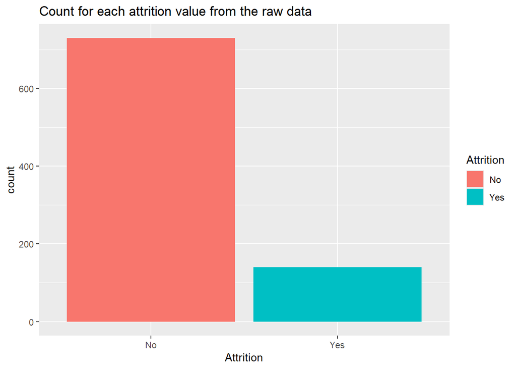

```r
emps %>% ggplot(aes(x=Attrition, fill=Attrition)) + geom_bar() + ggtitle("Count for each attrition value from the raw data")
```

## The need of balancing the data

Only 16% of data is for yes for attrition and rest of about 84% is no. This indicates imbalance of the data and can be a problem when we are training the model for the predicting attrition since less “yes” data might be hard for the model to predict which led the low specificity(the probability of number of correctly identified failures among true number of failures.) compared to high sensitivity and accuracy. Briefly, it means that the train model will be biased. Therefore, we need to balance the data.

```r
# When training with the raw data
set.seed(10)
splitPerc = 0.75
trainidx <- sample(1:dim(emps)[1], round(splitPerc * dim(emps)[1]))
train = emps[trainidx,]
test = emps[-trainidx,]

# demo running of the naiveBayes model.
library(e1071)
library(caret)
model = naiveBayes(train[, -c(3)], train$Attrition)
table(test$Attrition, predict(model, test[, -c(3)]))
```

```
##
##        No Yes
##   No  151  34
##   Yes  15  18
```

```r
confusionMatrix(table(test$Attrition, predict(model, test[, -c(3)])))
```

```
## Confusion Matrix and Statistics
##
##
##        No Yes
##   No  151  34
##   Yes  15  18
##
##                Accuracy : 0.7752
##                  95% CI : (0.714, 0.8288)
##     No Information Rate : 0.7615
##     P-Value [Acc > NIR] : 0.34997
##
##                   Kappa : 0.2925
##
##  Mcnemar's Test P-Value : 0.01013
##
##             Sensitivity : 0.9096
##             Specificity : 0.3462
##          Pos Pred Value : 0.8162
##          Neg Pred Value : 0.5455
##              Prevalence : 0.7615
##          Detection Rate : 0.6927
##    Detection Prevalence : 0.8486
##       Balanced Accuracy : 0.6279
##
##        'Positive' Class : No
##
```

## Oversampling

Oversampling is a method to re-balance the distribution of data by increasing number of samples from the underrepresented class. By this technique, both value for attrition has each 730 samples.

```r
# Install and load ROSE if not already done
#install.packages("ROSE")
library(ROSE)
# Define the target size for a balanced dataset
target_size <- max(table(emps$Attrition)) * 2  # Twice the size of the majority class

# Apply oversampling
balanced_emps <- ovun.sample(Attrition ~ ., data = emps, method = "over", N = target_size)$data

# Check the balance of the Attrition variable
table(balanced_emps$Attrition)
```

```
##
##  No Yes
## 730 730
```

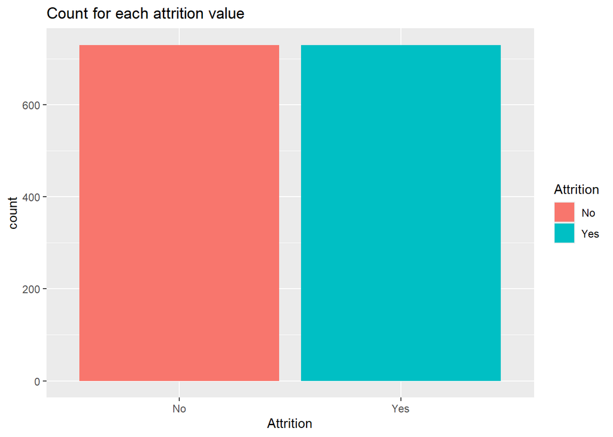

```r
# bar chart that shows that data is balanced
balanced_emps %>% ggplot(aes(x=Attrition, fill=Attrition)) + geom_bar() + ggtitle("Count for each attrition value")
```

## Is it really balanced?

Although according to the t.test, the p-value indicates that there is difference in mean between two. However, if we really look into mean of both samples, we can find that there is only 1 in mean difference. The reason is that since there are large samples, it is detecting small difference more easily. Ultimately, we can say that the oversampling well balanced the the data.

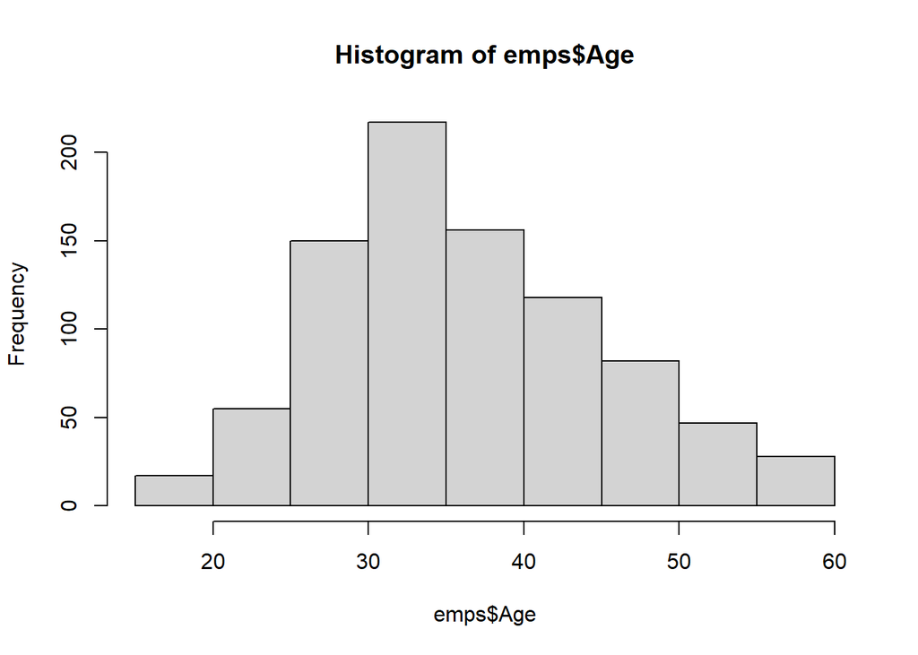

```r
# histogram of the raw data(emps) and the balanced data(balanced_emps)
# I took age since age has more variance which can be well shown with distribution.
hist(emps$Age)
```

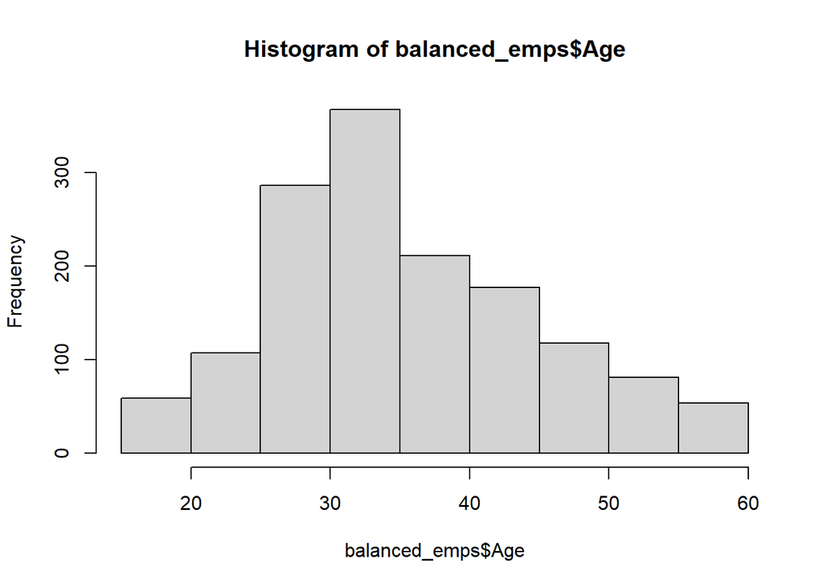

```r
hist(balanced_emps$Age)
```

```r
t.test(emps$Age, balanced_emps$Age, alternative = c("two.sided"), var.equal=TRUE)
```

```
##
##  Two Sample t-test
##
## data:  emps$Age and balanced_emps$Age
## t = 2.2995, df = 2328, p-value = 0.02157
## alternative hypothesis: true difference in means is not equal to 0
## 95 percent confidence interval:
##  0.1338841 1.6852310
## sample estimates:
## mean of x mean of y
##  36.82874  35.91918
```

### Base score with balanced data.

```r
# split the data set into 75% of train set and the 25% of test set.
set.seed(10)
splitPerc = 0.75
trainidx <- sample(1:dim(balanced_emps)[1], round(splitPerc * dim(balanced_emps)[1]))
train = balanced_emps[trainidx,]
test = balanced_emps[-trainidx,]

# for naive Bayes
library(e1071)

# For confusion Matrix
library(caret)

model = naiveBayes(train[, -c(3)], train$Attrition)
table(test$Attrition, predict(model, test[, -c(3)]))
```

```
##
##        No Yes
##   No  123  64
##   Yes  36 142
```

```r
confusionMatrix(table(test$Attrition, predict(model, test[, -c(3)])))
```

```
## Confusion Matrix and Statistics
##
##
##        No Yes
##   No  123  64
##   Yes  36 142
##
##                Accuracy : 0.726
##                  95% CI : (0.6772, 0.7712)
##     No Information Rate : 0.5644
##     P-Value [Acc > NIR] : 1.286e-10
##
##                   Kappa : 0.4538
##
##  Mcnemar's Test P-Value : 0.006934
##
##             Sensitivity : 0.7736
##             Specificity : 0.6893
##          Pos Pred Value : 0.6578
##          Neg Pred Value : 0.7978
##              Prevalence : 0.4356
##          Detection Rate : 0.3370
##    Detection Prevalence : 0.5123
##       Balanced Accuracy : 0.7315
##
##        'Positive' Class : No
##
```

### Take out irrelevant columns.

```r
# 1: ID
# 3: Attrition
# 10: EmployeeCount
# 11: EmployeeNumber
# 28: StandardHours
model = naiveBayes(train[, -c(1,3, 10, 11,28)], train$Attrition)
table(test$Attrition, predict(model, test[, -c(1,3, 10, 11,28)]))
```

```
##
##        No Yes
##   No  121  66
##   Yes  36 142
```

```r
confusionMatrix(table(test$Attrition, predict(model, test[,-c(1,3, 10, 11, 28)])))
```

```
## Confusion Matrix and Statistics
##
##
##        No Yes
##   No  121  66
##   Yes  36 142
##
##                Accuracy : 0.7205
##                  95% CI : (0.6715, 0.766)
##     No Information Rate : 0.5699
##     P-Value [Acc > NIR] : 1.904e-09
##
##                   Kappa : 0.443
##
##  Mcnemar's Test P-Value : 0.004086
##
##             Sensitivity : 0.7707
##             Specificity : 0.6827
##          Pos Pred Value : 0.6471
##          Neg Pred Value : 0.7978
##              Prevalence : 0.4301
##          Detection Rate : 0.3315
##    Detection Prevalence : 0.5123
##       Balanced Accuracy : 0.7267
##
##        'Positive' Class : No
##
```

# 3. Analysis

Now we are ready with the balanced data, we need to find out the factors that impacted Attrition.

## Question of the Interest 1: Department

According to the contigency table it seems like some of the factors that is directly related to job’s characteristics itself seems to have more distinction. I first looked into department to see if there are any significant differences.

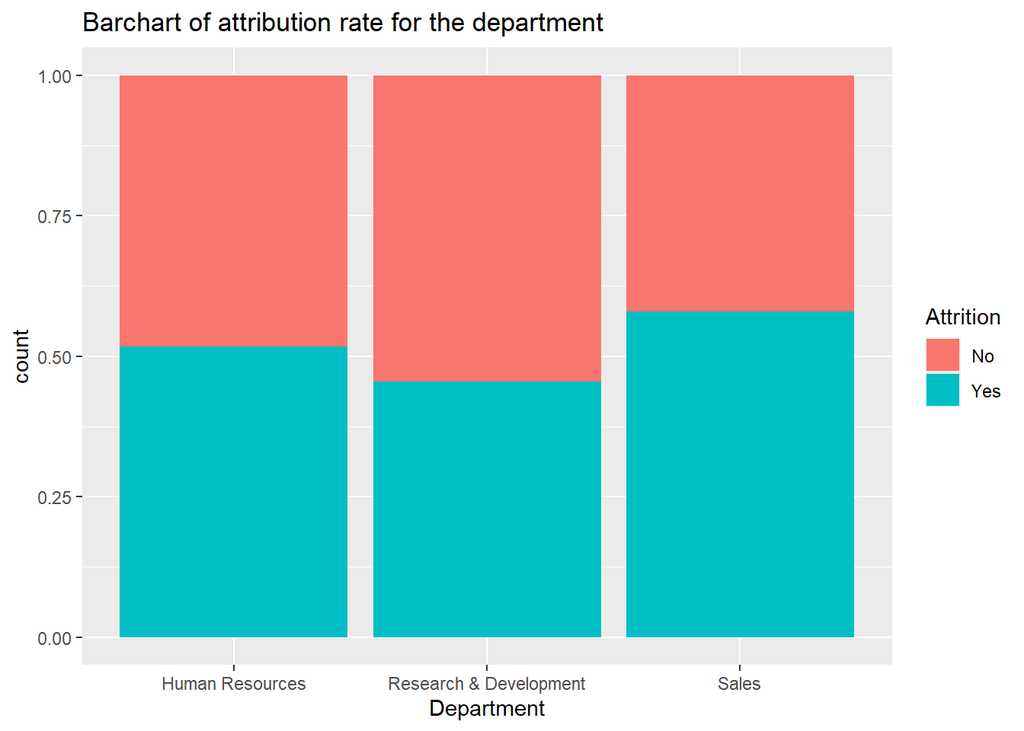

```r
balanced_emps %>% ggplot(aes(x = Department, fill = Attrition)) + geom_bar(position = "fill") + ggtitle("Barchart of attribution rate for the department")
```

# Questions of the interest 2 : Job Role

According to the barchart, Human Resources and Sales has high rate of attrition. Since there is a column of job role, we will what job roles are in what department and their attribution details.

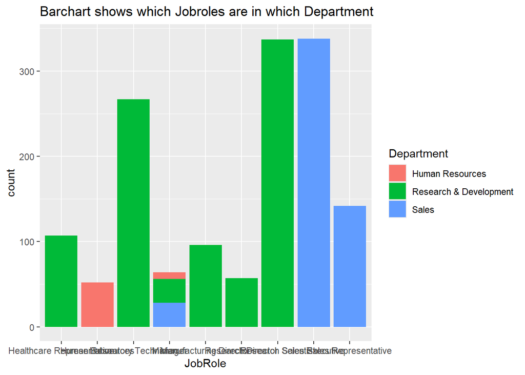

```r
balanced_emps %>% ggplot(aes(x=JobRole, fill=Department)) + geom_bar() + ggtitle("Barchart shows which Jobroles are in which Department")
```

Over here we can categorize that Sales: Sales Executive, Sales Representative Human Resource : Human Resources Research & Development : the rest without Manager Manager represents all department’s managers.

Now we will see if there’s any significant difference of attrition in terms of job role. JobRole in Sales department has higher rates in Attrition, Human Resources shows some of the attrition rate. The top 5 high attrition rate would be Sales Representative, Human Resources, Laboratory Technician, Research Scientist, and Sales Executive.

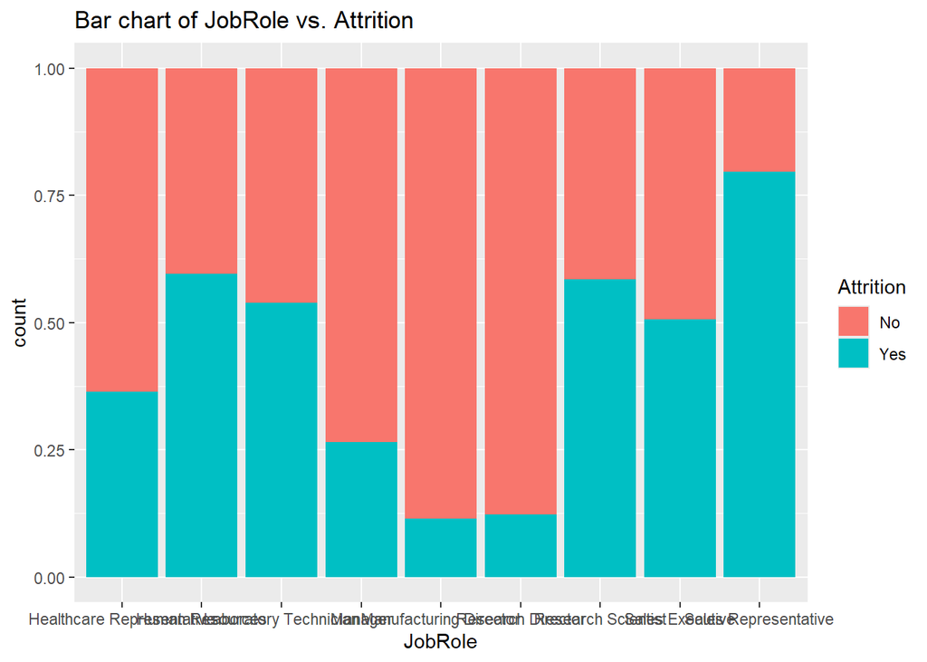

```r
balanced_emps %>% ggplot(aes(x = JobRole, fill=Attrition)) + geom_bar(position = "fill") + ggtitle("Bar chart of JobRole vs. Attrition")
```

## Question of Interest 3: Job Level

Since certain department sales and human resources are showing the higher attrition rate, does it has to do with their job level? Is it because the job is too simple? or because it is too difficult? The higher the job level is, the more competitive job skills and managing skills are needed. The red represents level 1 and they are largely distributed in certain Job roles such as Sales Representative, Human Resources, Laboratory Technician and Research Scientist. These match with the job role list that had higher attrition.

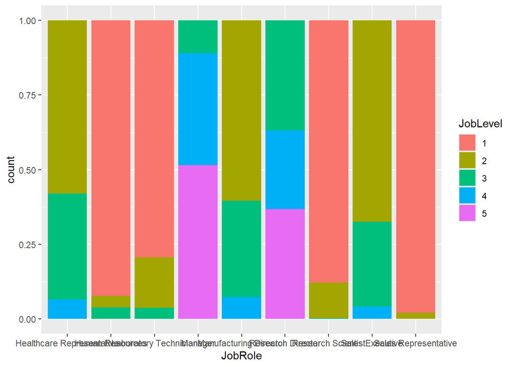

```r
balanced_emps$JobLevel <- as.factor(balanced_emps$JobLevel)
balanced_emps %>% ggplot(aes(x = JobRole, fill=JobLevel)) + geom_bar(position = "fill")
```

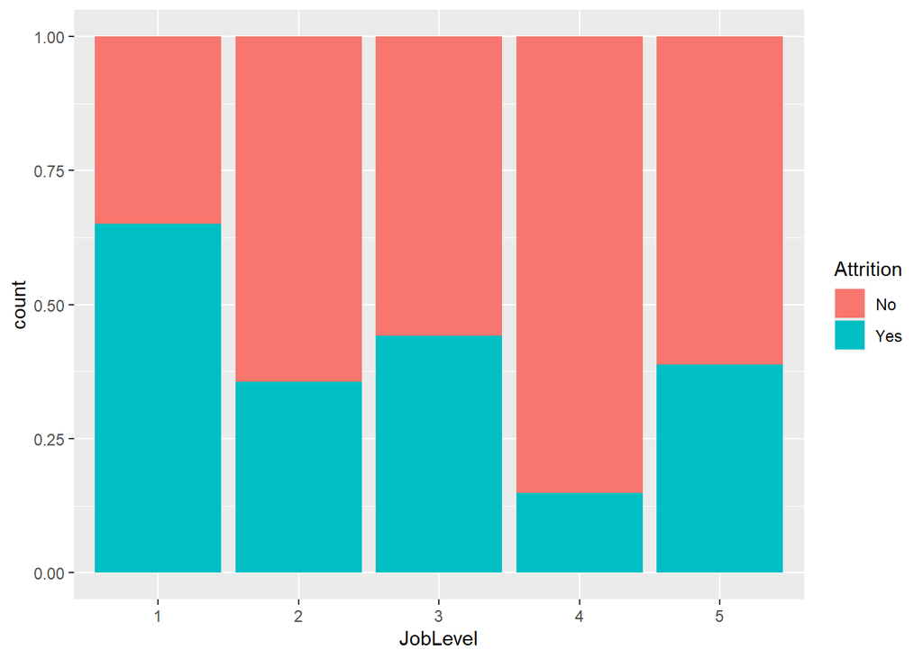

```r
balanced_emps %>% ggplot(aes(x = JobLevel, fill=Attrition)) + geom_bar(position = "fill")
```

Since Job level 1 requires just routine task and limited decision making jobs, it is likely that employeers leave the job.

### Question of Interest 4.

Does this affect the year of time that people stay for a job? According to the box plot, job roles that are showing lower years in current roles are Sales Representative, Human Resource, Research Scientist, Laboratory Technician and Sales Executive. The order and the group were exactly matched with the rank of job roles who that has higher attrition most.

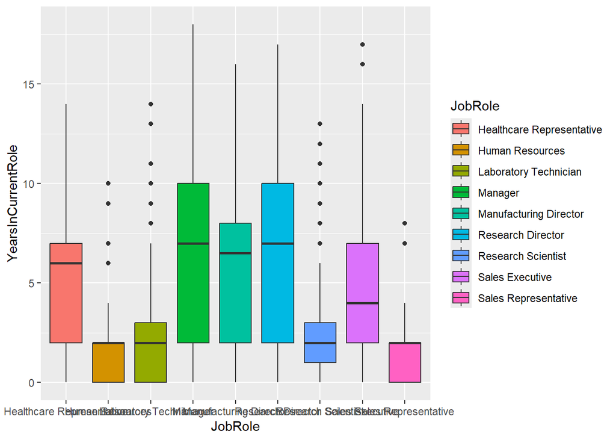

```r
balanced_emps %>% ggplot(aes(x= JobRole, y=YearsInCurrentRole, fill = JobRole)) + geom_boxplot()
```

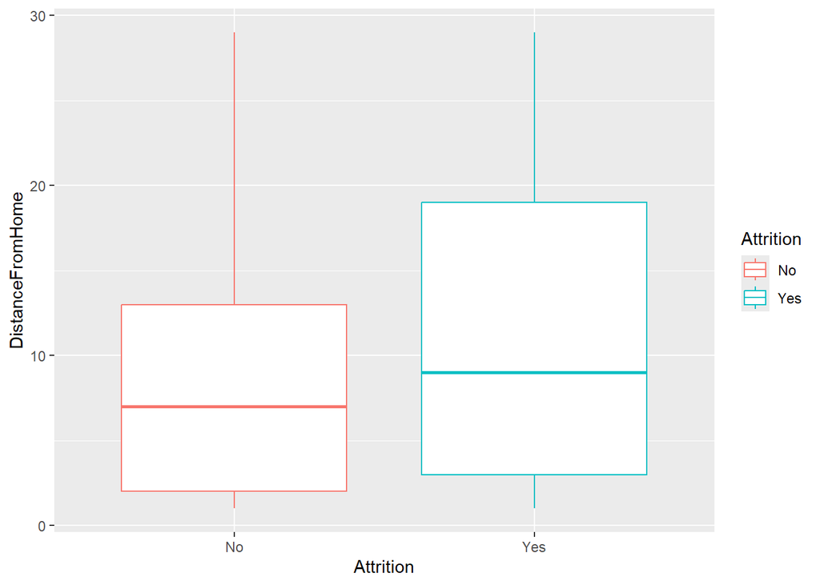

```r
balanced_emps %>% ggplot(aes(x = Attrition, y = DistanceFromHome, color=Attrition)) + geom_boxplot()
```

## Conlcusion

Three factors which are Job Role, Job Level and DistanceFromHome that are considered to be significantly impact the attrition according to the analysis. Since JobRole and Department are closely related, Department can be excluded. Also YearsInCurrentRole is closely related to JobRole will be excluded too. Now we will create a prediction model.

# 4. Prediction model - Naive Bayes Model

The model that is used for the prediction is naive base which has assumption that factors used for training are independent to each other. The model reached 71.5% for accuracy, 71.3% for sensitivity and 71.8% for the specificity. I took out these columns from the model that were made for The base score to see if it drops any of the statistics. And all three statistics had dropped.

```r
# 7 - DistanceFromHome - Employee Feature
# 15 - JobLevel - Job Environment
# 17- JobRole - Job features

model = naiveBayes(train[, c( 15, 17, 7)], train$Attrition)
table(test$Attrition, predict(model, test[, c(15,17, 7)]))
```

```
##
##        No Yes
##   No  139  48
##   Yes  56 122
```

```r
confusionMatrix(table(test$Attrition, predict(model, test[,c( 15, 17, 7)])))
```

```
## Confusion Matrix and Statistics
##
##
##        No Yes
##   No  139  48
##   Yes  56 122
##
##                Accuracy : 0.7151
##                  95% CI : (0.6658, 0.7608)
##     No Information Rate : 0.5342
##     P-Value [Acc > NIR] : 1.191e-12
##
##                   Kappa : 0.4292
##
##  Mcnemar's Test P-Value : 0.4925
##
##             Sensitivity : 0.7128
##             Specificity : 0.7176
##          Pos Pred Value : 0.7433
##          Neg Pred Value : 0.6854
##              Prevalence : 0.5342
##          Detection Rate : 0.3808
##    Detection Prevalence : 0.5123
##       Balanced Accuracy : 0.7152
##
##        'Positive' Class : No
##
```

```r
# Base Score
model = naiveBayes(train[, -c(1,3, 10, 11,28)], train$Attrition)
table(test$Attrition, predict(model, test[, -c(1,3, 10, 11,28)]))
```

```
##
##        No Yes
##   No  121  66
##   Yes  36 142
```

```r
confusionMatrix(table(test$Attrition, predict(model, test[,-c(1,3, 10, 11,28)])))
```

```
## Confusion Matrix and Statistics
##
##
##        No Yes
##   No  121  66
##   Yes  36 142
##
##                Accuracy : 0.7205
##                  95% CI : (0.6715, 0.766)
##     No Information Rate : 0.5699
##     P-Value [Acc > NIR] : 1.904e-09
##
##                   Kappa : 0.443
##
##  Mcnemar's Test P-Value : 0.004086
##
##             Sensitivity : 0.7707
##             Specificity : 0.6827
##          Pos Pred Value : 0.6471
##          Neg Pred Value : 0.7978
##              Prevalence : 0.4301
##          Detection Rate : 0.3315
##    Detection Prevalence : 0.5123
##       Balanced Accuracy : 0.7267
##
##        'Positive' Class : No
##
```

```r
# Take out three factors from the base model
model = naiveBayes(train[, -c(1,3, 10, 11,28, 15, 17, 7)], train$Attrition)
table(test$Attrition, predict(model, test[,  -c(1,3, 10, 11,28, 15, 17, 7)]))
```

```
##
##        No Yes
##   No  115  72
##   Yes  38 140
```

```r
confusionMatrix(table(test$Attrition, predict(model, test[, -c(1,3, 10, 11,28, 15, 17, 7)])))
```

```
## Confusion Matrix and Statistics
##
##
##        No Yes
##   No  115  72
##   Yes  38 140
##
##                Accuracy : 0.6986
##                  95% CI : (0.6487, 0.7453)
##     No Information Rate : 0.5808
##     P-Value [Acc > NIR] : 2.241e-06
##
##                   Kappa : 0.3997
##
##  Mcnemar's Test P-Value : 0.001653
##
##             Sensitivity : 0.7516
##             Specificity : 0.6604
##          Pos Pred Value : 0.6150
##          Neg Pred Value : 0.7865
##              Prevalence : 0.4192
##          Detection Rate : 0.3151
##    Detection Prevalence : 0.5123
##       Balanced Accuracy : 0.7060
##
##        'Positive' Class : No
##
```

# 5. Predict the data set

```r
model = naiveBayes(train[, c( 15, 17, 7)], train$Attrition)
table(test$Attrition, predict(model, test[, c(15,17, 7)]))
```

```
##
##        No Yes
##   No  139  48
##   Yes  56 122
```

```r
confusionMatrix(table(test$Attrition, predict(model, test[,c( 15, 17, 7)])))
```

```
## Confusion Matrix and Statistics
##
##
##        No Yes
##   No  139  48
##   Yes  56 122
##
##                Accuracy : 0.7151
##                  95% CI : (0.6658, 0.7608)
##     No Information Rate : 0.5342
##     P-Value [Acc > NIR] : 1.191e-12
##
##                   Kappa : 0.4292
##
##  Mcnemar's Test P-Value : 0.4925
##
##             Sensitivity : 0.7128
##             Specificity : 0.7176
##          Pos Pred Value : 0.7433
##          Neg Pred Value : 0.6854
##              Prevalence : 0.5342
##          Detection Rate : 0.3808
##    Detection Prevalence : 0.5123
##       Balanced Accuracy : 0.7152
##
##        'Positive' Class : No
##
```

```r
newtest = read.csv("/Users/oyunm/Desktop/SMU/DS-6306-Doing-the-Data-Science/project1/week8-case1/CaseStudy1CompSet No Attrition.csv")

newtest$Attrition <- NA
newtest <- newtest %>%
  select(1:2, Attrition, everything())


predicted_attritions = predict(model, test[, c(15,17, 7)])

# Save the test data in CSV file.
write.csv(predicted_attritions, "/Users/oyunm/Desktop/SMU/DS-6306-Doing-the-Data-Science/project1/week8-case1/Hayoung_cheon_predicted_attrition.csv", row.names = TRUE)
```

# 6. Youtube Link for the presentation

https://youtu.be/isHC_EplNu0